# Exercício avaliativo

```python
import io
import sqlite3
import pandas as pd
```

Neste exercício, vamos trabalhar com dados de uma empresa fictícia de consultoria.

**Considere o seguinte esquema relacional**:

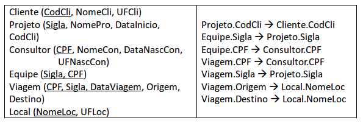

**assumindo as seguintes premissas**:

- Nenhum atributo admite valor nulo.
- Apenas as seguintes chaves primárias são numéricas: `Cliente.CodCli`, `Consultor.CPF`

# Download dos dados da empresa

```python
!wget --no-check-certificate -P /tmp/ https://homepages.dcc.ufmg.br/~rodrygo/static/ibd/consultoria.sql
```

```
--2025-05-18 15:04:40--  https://homepages.dcc.ufmg.br/~rodrygo/static/ibd/consultoria.sql
Resolving homepages.dcc.ufmg.br (homepages.dcc.ufmg.br)... 150.164.0.136
Connecting to homepages.dcc.ufmg.br (homepages.dcc.ufmg.br)|150.164.0.136|:443... connected.
WARNING: cannot verify homepages.dcc.ufmg.br's certificate, issued by ‘CN=GlobalSign RSA OV SSL CA 2018,O=GlobalSign nv-sa,C=BE’:
  Unable to locally verify the issuer's authority.
HTTP request sent, awaiting response... 200 OK
Length: 8832 (8.6K) [application/x-sql]
Saving to: ‘/tmp/consultoria.sql’

consultoria.sql     100%[===================>]   8.62K  --.-KB/s    in 0s

2025-05-18 15:04:41 (60.1 MB/s) - ‘/tmp/consultoria.sql’ saved [8832/8832]
```

# Carregando o banco

```python
conn = sqlite3.connect('/tmp/consultoria.db')
cursor = conn.cursor()

f = io.open('/tmp/consultoria.sql', 'r', encoding='utf-8')
sql = f.read()
cursor.executescript(sql)
```

```
<sqlite3.Cursor at 0x7f64817b08c0>
```

# Consultas

Responda as perguntas abaixo através de consultas SQL no banco de dados carregado.

O formato da célula de resposta pode ser visto na resposta da consulta exemplo 0.

**Você pode usar mais de uma célula para responder, desde que a última célula antes da próxima consulta contenha a resposta final no formato mostrado no exemplo 0.**

## 0. [exemplo/não alterar] Qual o nome e o número de viagens dos 5 consultores que mais viajaram a trabalho pela empresa IBD?

```python
query = """
SELECT
  C.NomeCon as Nome, COUNT(C.CPF) as NViagens
FROM
  Consultor as C
INNER JOIN Viagem as V
  ON C.CPF = V.CPF
GROUP BY
  C.CPF
ORDER BY
  NViagens DESC
LIMIT 5
"""

df = pd.read_sql_query(query, conn)
df
```

|  | Nome | NViagens |
| --- | --- | --- |
| 0 | Melissa Carvalho Cunha | 4 |
| 1 | Rodrigo Araujo Cardoso | 3 |
| 2 | Larissa Fernandes Araujo | 3 |
| 3 | Diogo Cavalcanti Rocha | 2 |
| 4 | Lucas Fernandes Costa | 1 |

## 1. Que consultores (CPF, nome e estado de nascimento) não nasceram em São Paulo (SP)?

```python
query= """
SELECT
   C.CPF as CPF, C.NomeCon as nome, C.UFNascCon as estadoDeNascimento
FROM
   Consultor as C
WHERE
   C.UFnascCon <> 'SP'
"""
df = pd.read_sql_query(query, conn)
df
```

|  | CPF | nome | estadoDeNascimento |
| --- | --- | --- | --- |
| 0 | 13414263351 | Samuel Araujo Azevedo | PR |
| 1 | 71960563530 | Diogo Cavalcanti Rocha | PB |
| 2 | 3074973994 | Julieta Maciel Sousa | RJ |
| 3 | 29762035631 | Caio Dias Ribeiro | MG |
| 4 | 17787063122 | Larissa Fernandes Araujo | MG |
| 5 | 31266012516 | Leonor Goncalves Rocha | MG |
| 6 | 85726311353 | Brenda Oliveira Goncalves | TO |

## 2. Que projetos (sigla e nome) não são do cliente "Facebook"?

```python
query= """
SELECT
    Sigla as sigla, NomePro as nome
FROM Cliente as C
    NATURAL JOIN Projeto
WHERE
    C.NomeCli <> "Facebook"
"""
df = pd.read_sql_query(query, conn)
df
```

|  | sigla | nome |
| --- | --- | --- |
| 0 | NMT | Neural Machine Translation (Chinês para Portug... |
| 1 | Search | Otimização Sistema de Busca |
| 2 | Spam | Detecção de Spam (Gmail) |
| 3 | Fake | Detecção de Fake News |
| 4 | SDC | Self Driving Car |
| 5 | Pay | Sistema de Pagamento |
| 6 | RecSys | Sistema de Recomendação |
| 7 | Fraud | Detecção de Fraude |

## 3. Para que UFs viajaram os consultores que participam do projeto de sigla "RecSys"?

```python
query="""
SELECT DISTINCT UFLoc as UF
FROM Local
JOIN
    (SELECT
       Sigla, Destino
     FROM
        Equipe
        NATURAL JOIN Viagem
     WHERE
        Sigla = "RecSys"
    ) as sub
ON sub.Destino = Local.NomeLoc
"""
df = pd.read_sql_query(query, conn)
df
```

|  | UF |
| --- | --- |
| 0 | MG |
| 1 | SP |

## 4. Que projetos (sigla e nome) não têm equipe?

```python
query= """
SELECT
    P.Sigla as sigla, P.NomePro as Nome
FROM Projeto as P
    LEFT JOIN Equipe as E
    ON P.Sigla = E.Sigla
WHERE
    E.CPF IS NULL
"""
df = pd.read_sql_query(query, conn)
df
```

|  | sigla | Nome |
| --- | --- | --- |
| 0 | Search | Otimização Sistema de Busca |
| 1 | Fake | Detecção de Fake News |
| 2 | SDC | Self Driving Car |

## 5. Que projetos (sigla e nome) não têm em sua equipe consultores nascidos antes de 1987?

```python
query= """
SELECT P.Sigla, P.NomePro
FROM Projeto AS P
  JOIN Equipe AS E ON E.Sigla = P.Sigla
  JOIN Consultor AS C ON C.CPF = E.CPF
GROUP BY P.Sigla, P.NomePro
HAVING MIN(strftime('%Y', C.DataNascCon)) >= '1987'
"""
df = pd.read_sql_query(query, conn)
df
```

|  | SIGLA | NOMEPRO |
| --- | --- | --- |
| 0 | Fraud | Detecção de Fraude |
| 1 | NMT | Neural Machine Translation (Chinês para Portug... |
| 2 | RecSys | Sistema de Recomendação |
| 3 | Spam | Detecção de Spam (Gmail) |
| 4 | VR | Hardware para Oculus VR |

## 6. Que consultores (CPF e nome) viajaram por seu estado natal (origem ou destino)?

```python
query= """
SELECT C.NomeCon as nome, C.CPF as CPF
FROM Consultor as C
JOIN
    (SELECT L.UFLoc, V.CPF
     FROM Viagem as V
     JOIN Local as L
     ON V.Origem = L.nomeLoc)
AS aux ON aux.CPF = C.CPF
WHERE
    C.UFNascCon = aux.UFLoc

UNION

SELECT C.NomeCon as nome, C.CPF as CPF
FROM Consultor as C
JOIN
    (SELECT L.UFLoc, V.CPF
     FROM Viagem as V
     JOIN Local as L
     ON V.Destino = L.nomeLoc)
AS aux ON aux.CPF = C.CPF
WHERE
    C.UFNascCon = aux.UFLoc
"""
df = pd.read_sql_query(query, conn)
df
```

|  | nome | CPF |
| --- | --- | --- |
| 0 | Caio Dias Ribeiro | 29762035631 |
| 1 | Larissa Fernandes Araujo | 17787063122 |
| 2 | Lucas Fernandes Costa | 62465487841 |
| 3 | Melissa Carvalho Cunha | 44434353608 |
| 4 | Rodrigo Araujo Cardoso | 34646193892 |

## 7. Para que locais não houve nenhuma viagem?

```python
query= """
SELECT DISTINCT L.nomeLoc as nome, L.UFLoc as UF
FROM Local as L
    LEFT JOIN Viagem as V
    ON L.nomeLoc = V.Destino
WHERE
    V.CPF IS NULL
"""
df = pd.read_sql_query(query, conn)
df
```

|  | nome | UF |
| --- | --- | --- |
| 0 | Amazon | WA |
| 1 | IBD-PR | PR |
| 2 | Netflix | CA |
| 3 | OpenAI | SF |
| 4 | Spotify | NY |

## 8. Em que projetos (sigla e nome) foram realizadas viagens para a California (CA) desde o início de 2019?

```python
query= """
SELECT aux.Sigla, aux.NomePro as nome
FROM
(SELECT V.Sigla, V.DataViagem, V.Destino, P.NomePro
 FROM Viagem as V
 JOIN Projeto as P ON P.Sigla = V.Sigla
 WHERE strftime('%Y', V.DataViagem) >= '2019'
) AS aux
JOIN Local as L ON aux.Destino = L.nomeLoc
WHERE L.UFLoc = 'CA'
"""
df = pd.read_sql_query(query, conn)
df
```

|  | Sigla | nome |
| --- | --- | --- |
| 0 | WhatsApp | Cliente desktop para o WhatsApp |
| 1 | VR | Hardware para Oculus VR |
| 2 | VR | Hardware para Oculus VR |

## 9. Que consultores (CPF e nome) viajaram por um projeto de cuja equipe não fazem parte?

```python
query= """
SELECT DISTINCT C.CPF, C.NomeCon AS nome
FROM Consultor AS C
    JOIN Viagem AS V ON V.CPF = C.CPF
    JOIN Projeto AS P ON V.Sigla = P.Sigla
    LEFT JOIN Equipe AS E ON E.CPF = C.CPF AND E.Sigla = P.Sigla
WHERE E.Sigla IS NULL;
"""
df = pd.read_sql_query(query, conn)
df
```

|  | CPF | nome |
| --- | --- | --- |
| 0 | 34646193892 | Rodrigo Araujo Cardoso |
| 1 | 44434353608 | Melissa Carvalho Cunha |

## 10. Que consultores (CPF e nome) não estão em nenhuma equipe de projeto que tenha iniciado em 2019?

```python
query = """
SELECT C.CPF, C.NomeCon AS nome
FROM Consultor AS C
WHERE C.CPF NOT IN (
    SELECT E.CPF
    FROM Equipe AS E
    JOIN Projeto AS P ON E.Sigla = P.Sigla
    WHERE strftime('%Y', P.DataInicio) = '2019')
"""
df = pd.read_sql_query(query, conn)
df
```

|  | CPF | nome |
| --- | --- | --- |
| 0 | 13414263351 | Samuel Araujo Azevedo |
| 1 | 71960563530 | Diogo Cavalcanti Rocha |
| 2 | 44434353608 | Melissa Carvalho Cunha |
| 3 | 62465487841 | Lucas Fernandes Costa |
| 4 | 3074973994 | Julieta Maciel Sousa |
| 5 | 29762035631 | Caio Dias Ribeiro |
| 6 | 34646193892 | Rodrigo Araujo Cardoso |
| 7 | 17787063122 | Larissa Fernandes Araujo |
| 8 | 31266012516 | Leonor Goncalves Rocha |
| 9 | 85726311353 | Brenda Oliveira Goncalves |